# MyFirstMarkdown

Add text here, just use it like a typewriter, and add as much or little as you’d like.

Second line of text.

Jacqueline

Bio Dept  
UVM

Use two or more blank spaces at the end of a single-spaced line

# Basic text formatting

Italic *Text*

Bold **Text**

Subscript<sub>text</sub>

Superscript<sup>Text</sup>

StrikethroughText

# Lists

- Item 1
- Item 2
  - Item 2a
  - Item 2b
1. Item 1
2. Item 2
3. Item 3
- Item 3a
- Item 3b

In line fencing with a backtick `like this is a good *example* of this` Can help make things more obvious.

In line execuation of r cose inside the backticks by inserting r as the first element 6.1415927

Last kind of fencing we can use, 3 backticks for a whole section

```
here it is being free and wild on its own
```

# Block qoutes `>`

> to be or not to be, calculus taught me this

Add a line between text

http://example.com

[linked phrase](http://example.com)

A [linked phrase](http://example.com/).

At the bottom of the document:

| First Header | Second Header |
| --- | --- |
| Content Cell | Content Cell |
| Content Cell | Content Cell |

# Latex code for equations

these equations such as $a = 3 + 4$ will appear in a single line of text.

## Subscripts

$$H_0 = z_{a + b}$$

## Superscripts

$$S = cA^z$$

Elements can be coupled and nested

$$S=cA^z_1+z_{2+x}$$

## Fractions and Greek Symbols

$$\alpha=\frac{\beta}{\delta + \gamma_x}$$

## Summations Signs

$$z=\sum_{i=1}^x{k}$$

## Escape the backslash with a custom term

$$\backslash \alpha \le b \backslash$$

## Rendering plaintext in a LaTex

$$P(Occurances of Species A) =Z$$

$$P(\mbox{Occurance of Species A})=z$$

```r
#Include yo comments
#preliminaries
library(ggplot2)
pred<--seq(1,10) #factor of 10 integers

res<--runif(10) # Random uniform values

## print the random number
print(res)
```

```
##  [1] -0.3509685 -0.4783825 -0.8853436 -0.1060645 -0.7835231 -0.8157158
##  [7] -0.6646961 -0.9018716 -0.8391812 -0.8937881
```

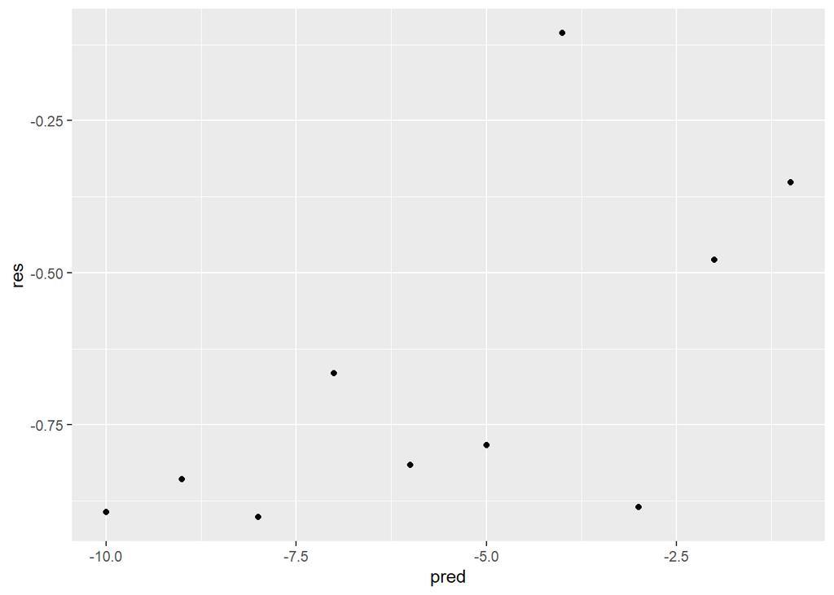

```r
#Plot the graph
qplot(x=pred,y=res)
```

Now back to writing text in our mark doc, including LateX eq. if we need these such as $a+b$ inserted in the middle of my sentence.